# Active Learning for Text Classification

# Classifying Wiki Detox Comments

Here we use a simple active learning approach for building a text classifier.

```r
### Libraries ###
library(dplyr)
library(ggplot2)
library(tidyr)
library(pROC)
# library(fastcluster)  # overwrites hclust

source("active_learning_lib.R")

FEATURIZED_DATA_FILE <- "featurized_wiki_comments_attack.Rds"
RANDOM_TS_PERFORMANCE_FILE <- "passive_learning_curves_data.Rds"
```

```r
params
```

```
## $seed
## [1] 1
##
## $initial_examples_per_class
## [1] 20
##
## $examples_to_label_per_iteration
## [1] 20
##
## $num_iterations
## [1] 20
##
## $presample_size
## [1] 200
##
## $monte_carlo_samples
## [1] 100
```

```r
set.seed(params$seed)

FEATURIZED_DATA <- readRDS(FEATURIZED_DATA_FILE)
FEATURIZED_DATA <- FEATURIZED_DATA[complete.cases(FEATURIZED_DATA),]

in_labeled_set <- sample(c(TRUE, FALSE), nrow(FEATURIZED_DATA), prob=c(0.09, 0.91), replace=TRUE)

labeled_data_df <- FEATURIZED_DATA[in_labeled_set,]
unlabeled_data_df <- FEATURIZED_DATA[!in_labeled_set,]

inputs <- grep("^V", names(labeled_data_df), value=TRUE)
outcome <- "flagged"
FORM <- formula(paste(outcome, paste(inputs, collapse="+"), sep="~"))
```

### Split labeled data into training and test sets

```r
initial_training_set <- labeled_data_df %>%
  group_by(flagged) %>%
  do(sample_n(., params$initial_examples_per_class)) %>%
  ungroup %>%
  as.data.frame

test_set_ids <- setdiff(labeled_data_df$rev_id, initial_training_set$rev_id)
TEST_SET <- labeled_data_df %>% filter(rev_id %in% test_set_ids)

table(initial_training_set$flagged)
```

```
##
## FALSE  TRUE
##    20    20
```

```r
table(TEST_SET$flagged)
```

```
##
## FALSE  TRUE
##  8870  1375
```

```r
table(TEST_SET$flagged)/nrow(TEST_SET)
```

```
##
##     FALSE      TRUE
## 0.8657882 0.1342118
```

## Case selection function

```r
select_cases <- function(model, available_cases, N=params$examples_to_label_per_iteration, presample_size=params$presample_size){
    presample_size <- min(nrow(available_cases), presample_size)
    candidate_cases <- available_cases[sample(1:nrow(available_cases), presample_size),]

    predictions_df <- rxPredict(model, candidate_cases, extraVarsToWrite=c("rev_id", "flagged"))

    predictions_df$entropy <- entropy(predictions_df$Probability)

    predictions_df$cluster_id <- predictions_df %>%
      dist(method="euclidean") %>%
      hclust(method="ward.D2") %>%
      cutree(k=N)

    selected <- predictions_df %>%
      group_by(cluster_id) %>%
      arrange(-entropy) %>%
      slice(which.max(entropy)) %>%
      as.data.frame

    return(selected)
}
```

## Initial model

First we build a model on the small number of examples in the initial training set, and test on the test data.

### Fit model to initial training set

```r
initial_model_results <- fit_and_evaluate_model(initial_training_set)
initial_model_results$selected <- select_cases(initial_model_results$model, unlabeled_data_df)
```

```
## Elapsed time: 00:00:00.0621616
```

### Results for initial model

#### ROC curve

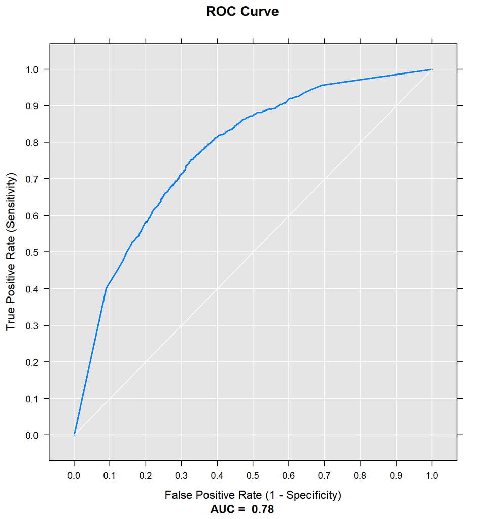

```r
plot(initial_model_results$roc, print.auc=TRUE)
```

#### Confusion matrix

```r
initial_model_results$confusion
```

```
##        PredictedLabel
## flagged FALSE TRUE
##   FALSE  5786 3084
##   TRUE    316 1059
```

#### Performance summary

```r
initial_model_results$performance
```

```
##         tss    accuracy neg_logloss         auc
##  40.0000000   0.6681308  -0.1452271   0.7757142
```

#### Histograms of class scores

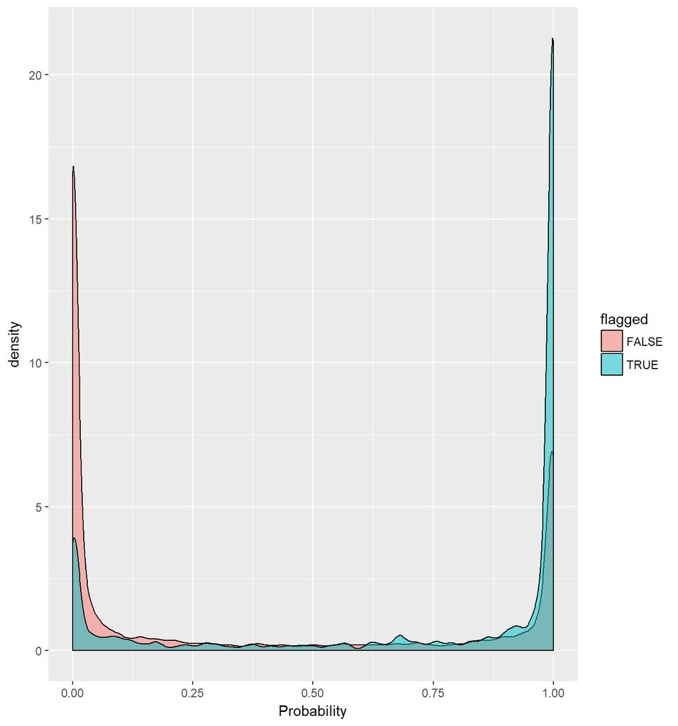

```r
plot_probability_distributions(initial_model_results, "initial model")
```

## Iterate modelling, case selection, and (pseudo) labelling

```r
# These are the cases selected by the initial model for labelling:
# initial_model_results$selected
```

```r
new_sample <- initial_model_results$selected %>% get_new_pseudolabeled_sample

current_training_set <- rbind(initial_training_set, new_sample[names(initial_training_set)])

ALREADY_EVALUATED <- initial_model_results$selected$rev_id

iteration_results <- lapply(1:params$num_iterations, function(i){
  results <- fit_and_evaluate_model(current_training_set)

  candidate_cases <- unlabeled_data_df[(unlabeled_data_df$rev_id %in% setdiff(unlabeled_data_df$rev_id,
                                                                                ALREADY_EVALUATED)),]
  results$selected <- select_cases(results$model, candidate_cases)

  ALREADY_EVALUATED <<- c(ALREADY_EVALUATED, results$selected$rev_id)

  next_sample <- results$selected %>% get_new_pseudolabeled_sample

  current_training_set <<- rbind(current_training_set, next_sample[names(current_training_set)])

  results
})
```

```
## Elapsed time: 00:00:00.0619624
## Elapsed time: 00:00:00.0629066
## Elapsed time: 00:00:00.0603936
## Elapsed time: 00:00:00.0620749
## Elapsed time: 00:00:00.0650780
## Elapsed time: 00:00:00.0682233
## Elapsed time: 00:00:00.0616894
## Elapsed time: 00:00:00.0685205
## Elapsed time: 00:00:00.0804964
## Elapsed time: 00:00:00.0765498
## Elapsed time: 00:00:00.0694454
## Elapsed time: 00:00:00.0801946
## Elapsed time: 00:00:00.0728009
## Elapsed time: 00:00:00.0819371
## Elapsed time: 00:00:00.0721124
## Elapsed time: 00:00:00.0660675
## Elapsed time: 00:00:00.0683419
## Elapsed time: 00:00:00.0787135
## Elapsed time: 00:00:00.0772941
## Elapsed time: 00:00:00.0671608
```

Mean entropy of selected samples by iteration:

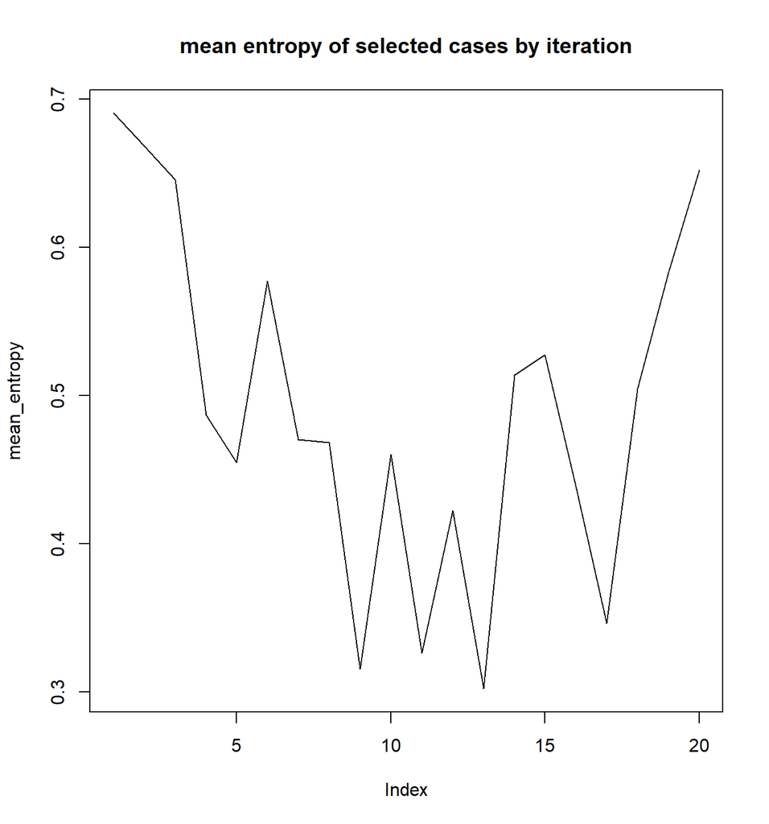

```r
mean_entropy <- sapply(iteration_results, function(ires) mean(ires$selected$entropy))
plot(mean_entropy, type='l', main="mean entropy of selected cases by iteration")
```

```r
# These are the cases selected at each iteration, together with the scores produced by the model for that iteration.
# lapply(iteration_results, function(ires) ires$selected)
```

```r
iteration_performance <- do.call("rbind", lapply(iteration_results, function(ires) ires$performance))


# iteration_performance <- bind_rows(lapply(iteration_results, function(ires) ires$performance))
(performance_table <- rbind(initial_model_results$performance, iteration_performance))
```

```
##       tss  accuracy neg_logloss       auc
##  [1,]  40 0.6681308  -0.1452271 0.7757142
##  [2,]  60 0.8044900  -0.3021404 0.7985086
##  [3,]  80 0.8038067  -0.3974600 0.7744209
##  [4,] 100 0.8539776  -0.4247624 0.8003347
##  [5,] 120 0.8706686  -0.4907101 0.7915524
##  [6,] 140 0.8778917  -0.4596596 0.8077230
##  [7,] 160 0.8819912  -0.5327288 0.7891826
##  [8,] 180 0.8846266  -0.5381007 0.7940136
##  [9,] 200 0.8812103  -0.5339648 0.7927267
## [10,] 220 0.8898975  -0.5765098 0.7887902
## [11,] 240 0.8862860  -0.6122007 0.7811460
## [12,] 260 0.8841386  -0.5609467 0.7900538
## [13,] 280 0.8888238  -0.5760268 0.7922154
## [14,] 300 0.8870669  -0.5670456 0.7935978
## [15,] 320 0.8874573  -0.5615427 0.7925034
## [16,] 340 0.8898975  -0.5489650 0.7971523
## [17,] 360 0.8880429  -0.5493280 0.7870784
## [18,] 380 0.8896047  -0.5161708 0.8057462
## [19,] 400 0.8933138  -0.5041057 0.8112849
## [20,] 420 0.8936066  -0.4863243 0.8096606
## [21,] 440 0.8941923  -0.4736474 0.8173509
```

### Comparing learning curves of active and passive learning

```r
get_random_training_set_performance <- function(ts_sizes){
  random_training_set <- initial_training_set

  random_training_set_results <- lapply(c(0,diff(ts_sizes)), function(tss){
    new_ids <- sample(setdiff(unlabeled_data_df$rev_id, random_training_set$rev_id), tss)
    new_cases <- unlabeled_data_df %>% filter(rev_id %in% new_ids)
    random_training_set <<- rbind(random_training_set, new_cases)
    fit_and_evaluate_model(random_training_set)
  })

  random_ts_performance <- random_training_set_results %>%
    lapply("[[", "performance") %>%
    do.call(bind_rows, .)

  random_ts_performance$sample_selection_mode <- "random"

  random_ts_performance
}

performance_table <- as.data.frame(performance_table)
ts_sizes <- performance_table$tss

if (file.exists(RANDOM_TS_PERFORMANCE_FILE)){
  random_ts_performance_list <- readRDS(RANDOM_TS_PERFORMANCE_FILE)
} else {
  NUM_TSS_COMPARISONS <- 3
  random_ts_performance_list <- lapply(1:NUM_TSS_COMPARISONS, function(i){
    rtsp <- get_random_training_set_performance(ts_sizes)
    rtsp$group <- i
    rtsp
  })

  saveRDS(random_ts_performance_list, RANDOM_TS_PERFORMANCE_FILE)
}

performance_table$sample_selection_mode <- "active"
performance_table$group <- 0

performance_data <- bind_rows(random_ts_performance_list, performance_table)
names(performance_data)[6] <- "run"
```

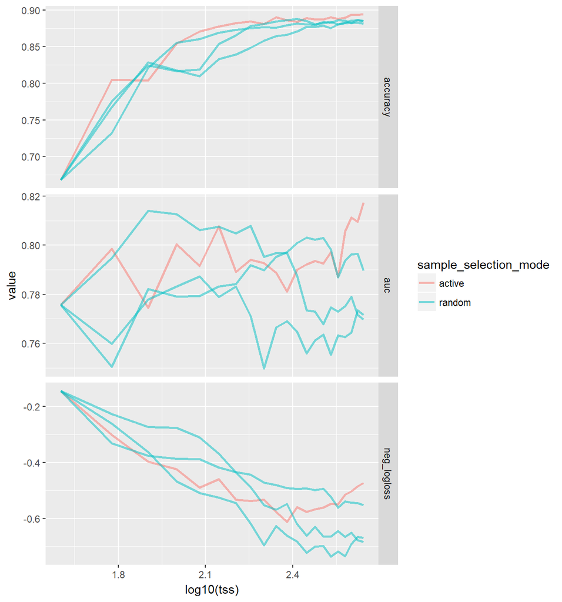

```r
performance_data %>%
  gather(key="metric", value="value", -tss, -sample_selection_mode, -run) %>%
  ggplot(aes(x=log10(tss), y=value, col=sample_selection_mode, group=run)) +
    geom_line(size=1, alpha=0.5) +
    facet_grid(metric ~ ., scales="free")
```

### Visualizing improvement for actively learned model

```r
final_model_results <- iteration_results[[params$num_iterations]]
```

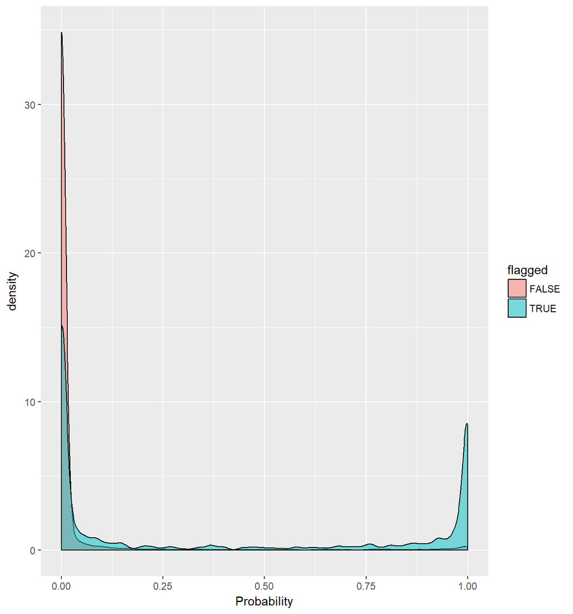

```r
plot_probability_distributions(final_model_results, "final model")
```

This series of ROC curves shows how performance changes with iterations of active learning.

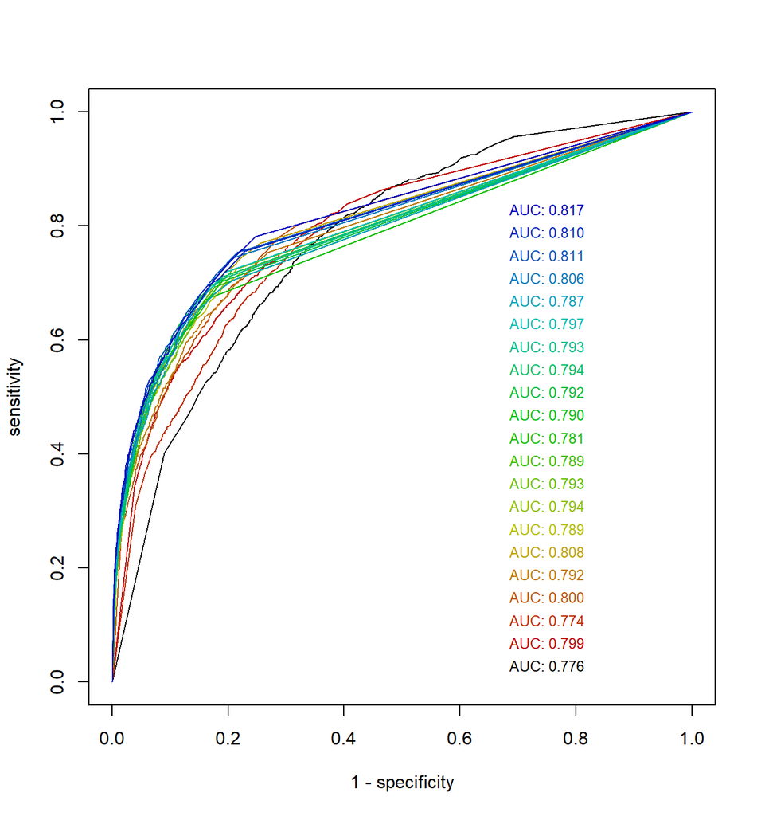

```r
plot_roc_history(initial_model_results, iteration_results)
```

## Final model results

### Confusion Matrix

```r
final_model_results$confusion
```

```
##        PredictedLabel
## flagged FALSE TRUE
##   FALSE  8601  269
##   TRUE    815  560
```

### Performance summary

Summary of performance using cases selected with active learning:

```r
(selected_sample_results <- final_model_results$performance)
```

```
##         tss    accuracy neg_logloss         auc
## 440.0000000   0.8941923  -0.4736474   0.8173509
```

## Monte Carlo Estimation of P-values

What is the probability that a set of randomly chosen cases would improve the performance of the model as much as the selected cases did? We’ll add the same number of examples to the training set, except that now they will be randomly chosen. We’ll repeat this sampling, training, and evaluation process 100 times, and see how many of those times we beat the performance of the selected cases.

```r
(N <- iteration_results[[params$num_iterations]]$performance[['tss']] - nrow(initial_training_set))
```

```
## [1] 400
```

```r
available_cases <- unlabeled_data_df

random_sample_results <- sapply(1:params$monte_carlo_samples, function(i){
  new_sample <- available_cases[sample(1:nrow(available_cases), N, replace=FALSE),]

  training_set_new <- rbind(initial_training_set, new_sample[names(initial_training_set)])

  fit_and_evaluate_model(training_set_new)$performance
})
```

### P-values

```r
mapply (
  function(metric) sum(random_sample_results[metric,] >= selected_sample_results[[metric]]),
  row.names(random_sample_results)
) / params$monte_carlo_samples
```

```
##         tss    accuracy neg_logloss         auc
##        1.00        0.00        0.01        0.01
```

## Model trained with all available “unlabeled” cases

For comparison, we’ll build a model as though we had gone through and labeled all 105089 of the usable new examples.

```r
training_set_full <- rbind(initial_training_set, available_cases[names(initial_training_set)])

full_model_results <- fit_and_evaluate_model(training_set_full)

full_model_results$confusion
```

```
##        PredictedLabel
## flagged FALSE TRUE
##   FALSE  8674  196
##   TRUE    760  615
```

```r
full_model_results$performance
```

```
##           tss      accuracy   neg_logloss           auc
##  1.051290e+05  9.066862e-01 -1.592932e-01  8.950103e-01
```

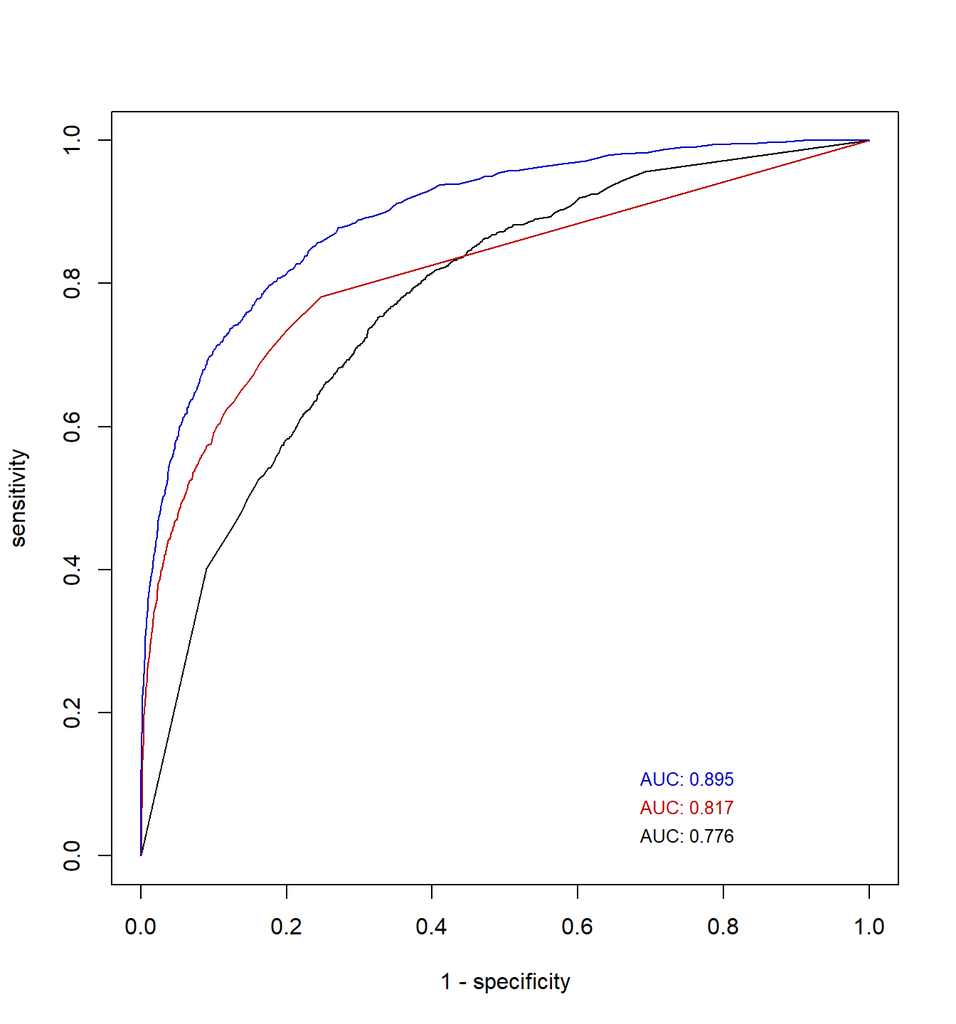

```r
plot_roc_history(initial_model_results, list(final_model_results, full_model_results))
```

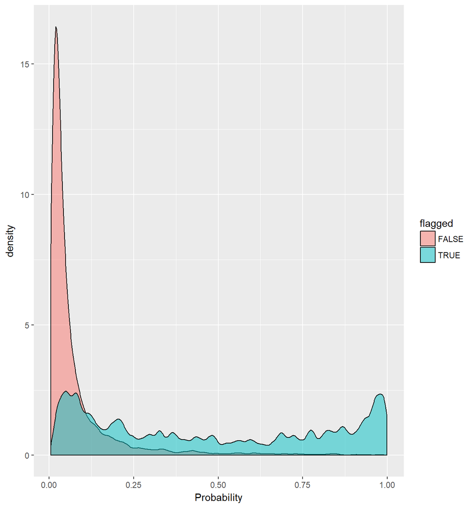

```r
plot_probability_distributions(full_model_results, "full model")
```